# GroundWater

Rozerin Yıldız Peteksu Karpuz

04 06 2022

- **Project Description**
- **Description of problem**
- Groundwater quality monitoring is carried out under the State Environmental Monitoring coordinated by the Chief Inspector of Environmental Protection. The purpose of groundwater quality monitoring is to provide information on the chemical status of groundwater, track its changes and signal threats on a national scale, for the purposes of managing groundwater resources and assessing the effectiveness of protective measures taken.
- **Dataset**
- Dataset : https://www.kaggle.com/datasets/krystianadammolenda/poland-2020
- Monitoring of groundwater quality dataset.
- 55 Column - 769 Row
- **Columns**
- ID : Ordinal number of each of the saved measurements
- UE_ID_MEASURING_POINT : UE identifier of the measuring point
- X_PL1992 : Coordinate ‘x’ according to the PL-1992 National Geodetic Coordinate System
- Y_PL1992 : Coordinate ‘y’ according to the PL-1992 National Geodetic Coordinate System
- VOIVODESHIP : Name of the voivodeship in English (in Polish in brackets)
- DISTRICT : Name of the poviat (district) in Polish
- COMMUNITY : Name of the commune in Polish
- CITY : The name of the city in Polish
- BASIN_NAME : River basin name
- CAT_LAND : Land use category
- DATE_SAMPLING : Date of sampling
- CONDUCT_FIELD : Specific electrolytic conductivity at 20 °C - field value [µS/cm]
- PH_FIELD : pH value - field value [-]
- TEMP_FIELD : Temperature - field value [°C]
- O2_DISSOL_FIELD : Dissolved oxygen - field value [mgO₂/l]
- CONDUCT_LAB : Specific electrolytic conductivity at 20 °C - laboratory value [µS/cm]
- PH_LAB : pH value - laboratory value [-]
- CON_C : Organic carbon concentration [mgC/l]
- CON_NH4+ : Ammonium ions concentration [mgNH₄⁺/l]
- CON_Sb : Antimony concentration [mgSb/l]
- CON_As : Arsenic concentration [mgAs/l]
- CON_NO3- : Nitrate(V) ions concentration [mgNO₃⁻/l]
- CON_NO2- : Nitrate(III) ions concentration [mgNO₂⁻/l]
- CON_Ba : Barium concentration [mgBa/l]
- CON_Be : Beryllium concentration [mgBe/l]
- CON_B : Boron concentration [mgB/l]
- CON_Cl- : Chloride ions concentration [mgCl⁻/l]
- CON_Cr : Chromium concentration [mgCr/l]
- CON_CN- : Cyanide ions concentration [mgCN⁻/l]
- CON_Sn : Tin concentration [mgSn/l]
- CON_Zn : Zinc concentration [mgZn/l]
- CON_F- : Fluoride ions concentration [mgF⁻/l]
- CON_PO43- : Phosphate(V) ion concentration [mgPO₄³⁻/l]
- CON_Al : Aluminum concentration [mgAl/l]
- CON_Cd : Cadmium concentration [mgCd/l]
- CON_Co : Cobalt concentration [mgCo/l]
- CON_Mg : Magnesium concentration [mgMg/l]
- CON_Mn : Manganese concentration [mgMn/l]
- CON_Cu : Copper concentration [mgCu/l]
- CON_Mo : Molybdenum concentration [mgMo/l]
- CON_Ni : Nickel concentration [mgNi/l]
- CON_Pb : Lead concentration [mgPb/l]
- CON_K : Potassium concentration [mgK/l]
- CON_Hg : Mercury concentration [mgHg/l]
- CON_Se : Selenium concentration [mgSe/l]
- CON_SO42 : Sulfate(VI) ions concentration [mgSO₄ ²⁻/l]
- CON_Na : Sodium concentration [mgNa/l]
- CON_Ag : Silver concentration [mgAg/l]
- CON_Tl : Thallium concentration [mgTl/l]
- CON_Tl : Titanium concentration [mgTi/l]
- CON_U : Uranium concentration [mgU/l]
- CON_v : Vanadium concentration [mgV/l]
- CON_Ca : Calcium concentration [mgCa/l]
- CON_HCO3 : Bicarbonate ions concentration [mgHCO⁻/l]
- CON_Fe : Iron concentration [mgFe/l]
- **Categorical data columns : BASIN_NAME, CITY, UE_ID_MEASURING_POINT, VOIVODESHIP, DISTRICT, COMMUNITY, CAT_LAND**
- **Ordinal data columns : DATE_SAMPLING**
- **Quantitative data columns: The rest of the other columns.**
- **Loading dataset**

```r
dataset <- read.csv("C:\\Users\\petek\\Desktop\\Groundwater_parameters.csv")
```

```r
head(dataset, n=5)
```

```
##   ID UE_ID_MEASURING_POINT X_PL1992 Y_PL1992                    VOIVODESHIP
## 1  1          PL600034_011 310941.2 559486.8 Greater Poland (wielkopolskie)
## 2  2          PL600034_011 310941.2 559486.8 Greater Poland (wielkopolskie)
## 3  3          PL600034_007 324104.9 579237.1 Greater Poland (wielkopolskie)
## 4  4          PL600034_007 324104.9 579237.1 Greater Poland (wielkopolskie)
## 5  5          PL600034_005 324112.6 579243.0 Greater Poland (wielkopolskie)
##                  DISTRICT                       COMMUNITY    CITY BASIN_NAME
## 1 czarnkowsko-trzcianecki    Wielen (gm. miejsko-wiejska) Beglewo Odra basin
## 2 czarnkowsko-trzcianecki    Wielen (gm. miejsko-wiejska) Beglewo Odra basin
## 3 czarnkowsko-trzcianecki Trzcianka (gm. miejsko-wiejska) Stradun Odra basin
## 4 czarnkowsko-trzcianecki Trzcianka (gm. miejsko-wiejska) Stradun Odra basin
## 5 czarnkowsko-trzcianecki Trzcianka (gm. miejsko-wiejska) Stradun Odra basin
##                   CAT_LAND DATE_SAMPLING CONDUCT_FIELD PH_FIELD TEMP_FIELD
## 1 09. Meadows and pastures     6/16/2020           413     8.00       10.8
## 2 09. Meadows and pastures     9/23/2020           530     7.90       10.7
```

[output cut: 33 more lines]

- **Data Summary**

```r
summary(dataset)
```

```
##        ID      UE_ID_MEASURING_POINT    X_PL1992         Y_PL1992
##  Min.   :  1   Length:769            Min.   :185897   Min.   :177070
##  1st Qu.:193   Class :character      1st Qu.:404400   1st Qu.:289627
##  Median :385   Mode  :character      Median :487021   Median :392420
##  Mean   :385                         Mean   :485062   Mean   :429327
##  3rd Qu.:577                         3rd Qu.:535124   3rd Qu.:524516
##  Max.   :769                         Max.   :827596   Max.   :766570
##
##  VOIVODESHIP          DISTRICT          COMMUNITY             CITY
##  Length:769         Length:769         Length:769         Length:769
##  Class :character   Class :character   Class :character   Class :character
##  Mode  :character   Mode  :character   Mode  :character   Mode  :character
##
##
##
##
##   BASIN_NAME          CAT_LAND         DATE_SAMPLING      CONDUCT_FIELD
##  Length:769         Length:769         Length:769         Min.   :  86.0
##  Class :character   Class :character   Class :character   1st Qu.: 399.0
##  Mode  :character   Mode  :character   Mode  :character   Median : 547.0
##                                                           Mean   : 591.4
##                                                           3rd Qu.: 696.0
##                                                           Max.   :2937.0
##                                                           NA's   :4
##     PH_FIELD       TEMP_FIELD    O2_DISSOL_FIELD   CONDUCT_LAB
##  Min.   :4.750   Min.   : 8.20   Min.   : 0.000   Min.   :  82.0
##  1st Qu.:6.920   1st Qu.:10.20   1st Qu.: 0.160   1st Qu.: 401.0
##  Median :7.200   Median :10.70   Median : 0.550   Median : 544.0
##  Mean   :7.143   Mean   :10.95   Mean   : 2.214   Mean   : 583.7
##  3rd Qu.:7.420   3rd Qu.:11.50   3rd Qu.: 3.710   3rd Qu.: 693.0
##  Max.   :9.100   Max.   :18.70   Max.   :16.600   Max.   :2922.0
##
##      PH_LAB          CON_C           CON_NH4.           CON_Sb
##  Min.   :5.120   Min.   : 0.000   Min.   : 0.0000   Min.   :0.000e+00
##  1st Qu.:6.990   1st Qu.: 0.000   1st Qu.: 0.0000   1st Qu.:0.000e+00
##  Median :7.250   Median : 0.000   Median : 0.1700   Median :0.000e+00
##  Mean   :7.165   Mean   : 2.284   Mean   : 0.7779   Mean   :2.913e-05
##  3rd Qu.:7.430   3rd Qu.: 1.700   3rd Qu.: 0.5700   3rd Qu.:0.000e+00
##  Max.   :9.040   Max.   :75.000   Max.   :53.0000   Max.   :9.900e-04
##
```

[output cut: 57 more lines]

```
##  Min.   :0.0000000   Min.   :0.00000   Min.   :0.0000000   Min.   :  6.20
##  1st Qu.:0.0000000   1st Qu.:0.00000   1st Qu.:0.0000000   1st Qu.: 55.80
##  Median :0.0000000   Median :0.00006   Median :0.0000000   Median : 81.80
##  Mean   :0.0002302   Mean   :0.00113   Mean   :0.0003953   Mean   : 84.55
##  3rd Qu.:0.0000000   3rd Qu.:0.00062   3rd Qu.:0.0000000   3rd Qu.:107.20
##  Max.   :0.0350000   Max.   :0.15006   Max.   :0.0130000   Max.   :407.40
##
##    CON_HCO3.          CON_Fe
##  Min.   :   0.0   Min.   :  0.000
##  1st Qu.: 166.0   1st Qu.:  0.030
##  Median : 259.0   Median :  1.050
##  Mean   : 262.5   Mean   :  3.365
##  3rd Qu.: 333.0   3rd Qu.:  3.680
##  Max.   :1110.0   Max.   :112.410
##
```

- **Data visualization and descriptive stats**

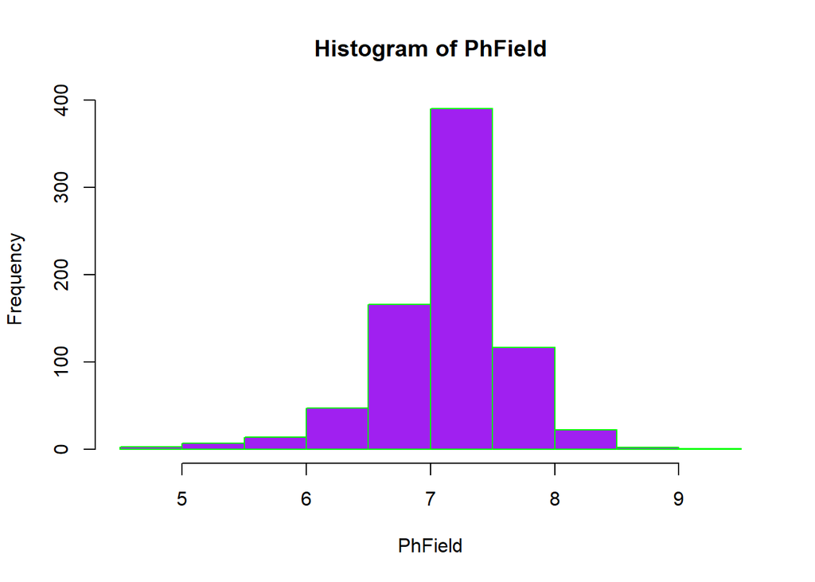

```r
PhField <- dataset$PH_FIELD
hist(PhField,col = "purple",border = "green")
```

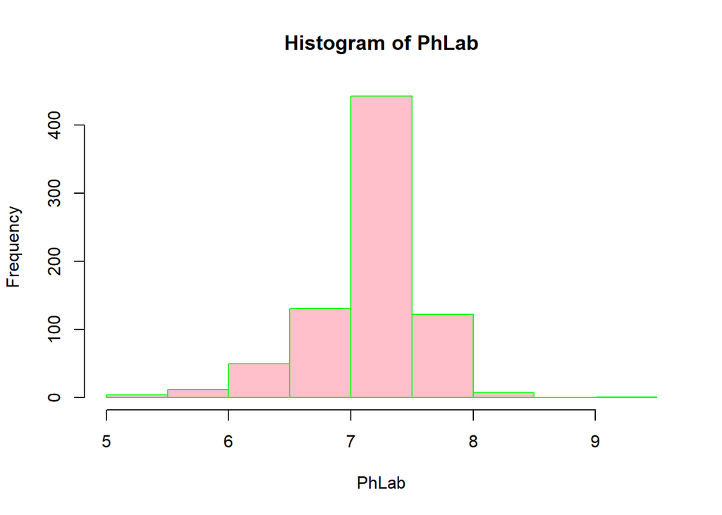

```r
PhLab <- dataset$PH_LAB
hist(PhLab,col = "pink",border = "green")
```

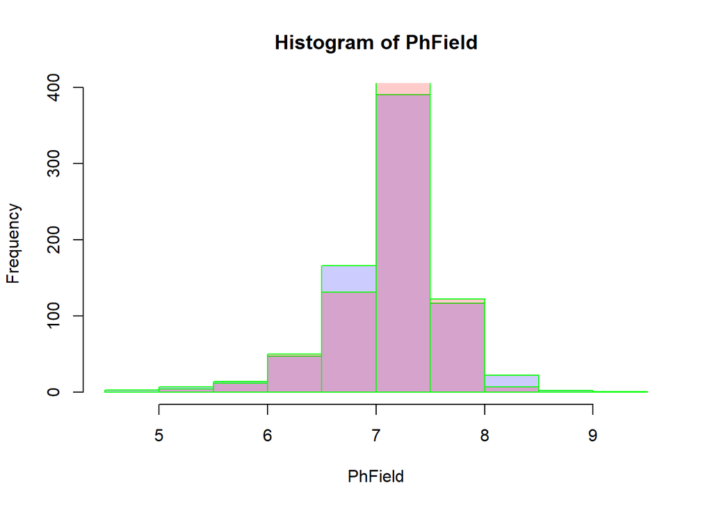

```r
hist(PhField, col = rgb(0,0,1,0.2),border = "green")
hist(PhLab, col = rgb(1,0,0,0.2),border = "green", add=TRUE)
```

- According to the histogram showing the relationship between pH field value and pH lab value, the frequency values were very similar to each other, as we have seen in the previous histograms.

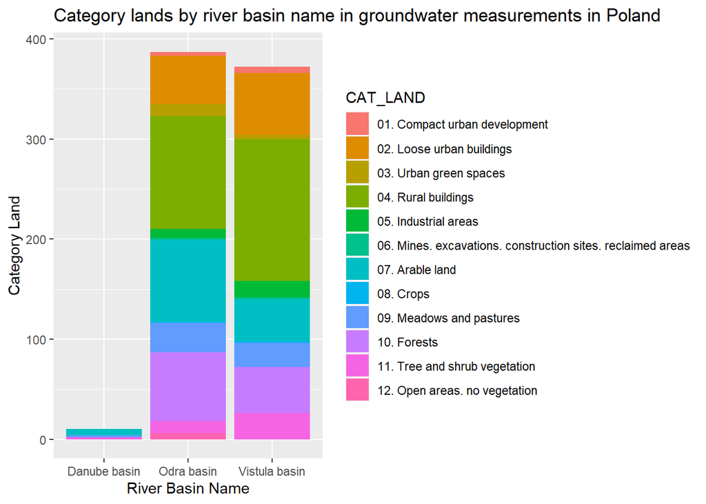

```r
library(ggplot2)
library(tidyverse)
library(hrbrthemes)
library(ggpubr)
library(moments)
  ggplot(dataset, aes(x=BASIN_NAME, fill=CAT_LAND))+
  geom_bar() +
  labs(title = "Category lands by river basin name in groundwater measurements in Poland",x= "River Basin Name",y= "Category Land")
```

- As seen on the above bar chart, Odra Basin and Vistula Basin has more lines than Danube Basin.

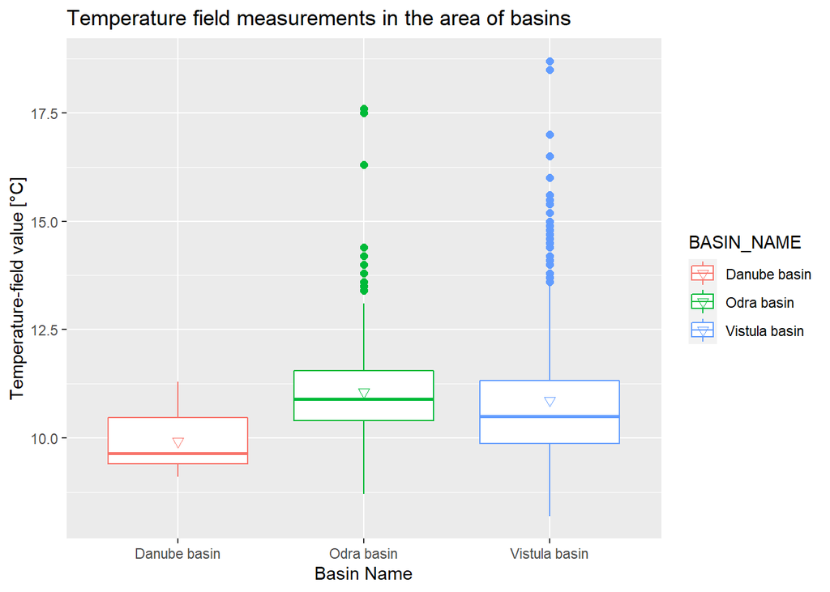

```r
ggplot(dataset, aes(x=BASIN_NAME, y=TEMP_FIELD, color= BASIN_NAME)) +
  geom_boxplot(outlier.size=2) + stat_summary(fun=mean, geom="point", shape=6, size=2) +
  labs(title = "Temperature field measurements in the area of basins",x= "Basin Name",y= "Temperature-field value [°C]")
```

- When we compared the temperature field value based on basins, we see that Vistula Basin has the highest range and Odra Basin has the highest mean.

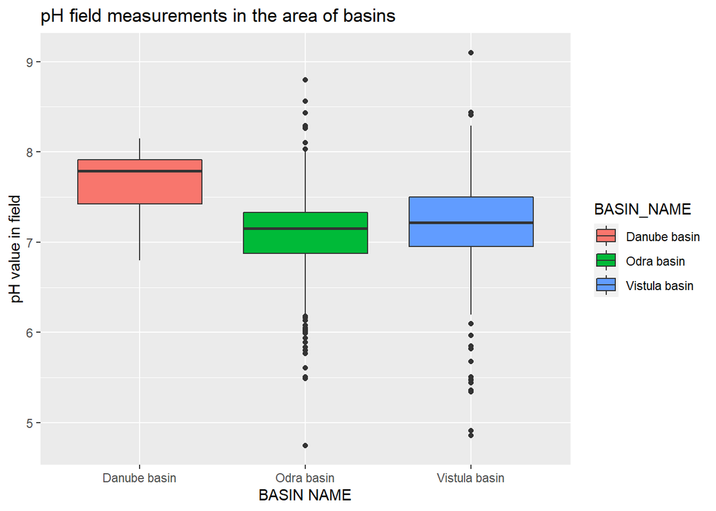

```r
ggplot(data=dataset, aes(x=BASIN_NAME, y=PH_FIELD, fill=BASIN_NAME)) +
  geom_boxplot() +
  labs(title = "pH field measurements in the area of basins", x="BASIN NAME", y="pH value in field")
```

- When we compared the pH field value based on basins, we see that Vistula Basin has the highest range and Danube Basin has the highest mean.

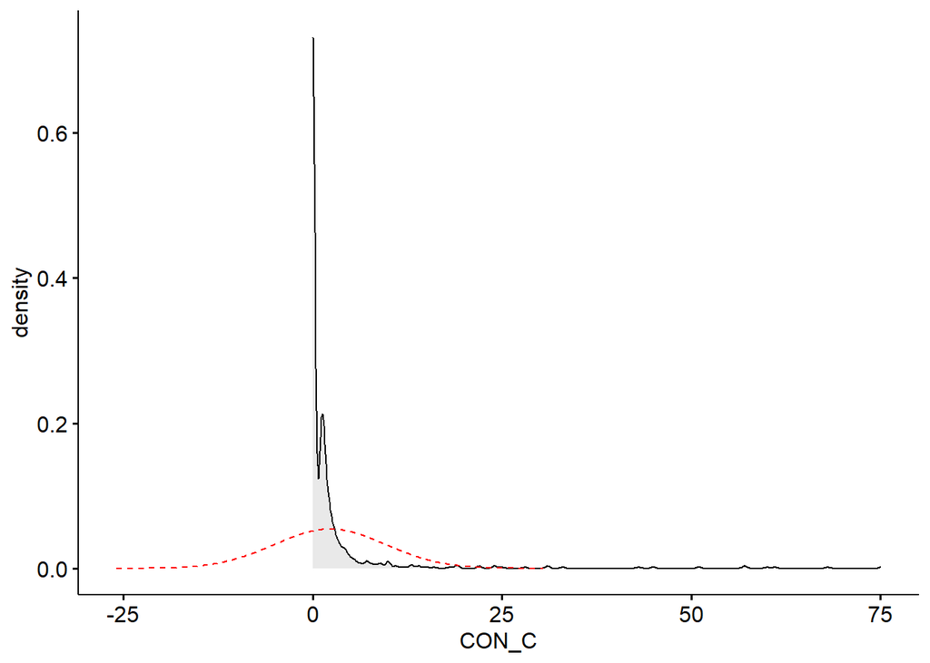

```r
ggdensity(dataset, x = "CON_C", fill = "lightgray") +
  scale_x_continuous() +
  stat_overlay_normal_density(color = "red", linetype = "dashed")
```

- According to ggdensity, the density of the CON_C observed in the groundwater appears to be highly right skewed.

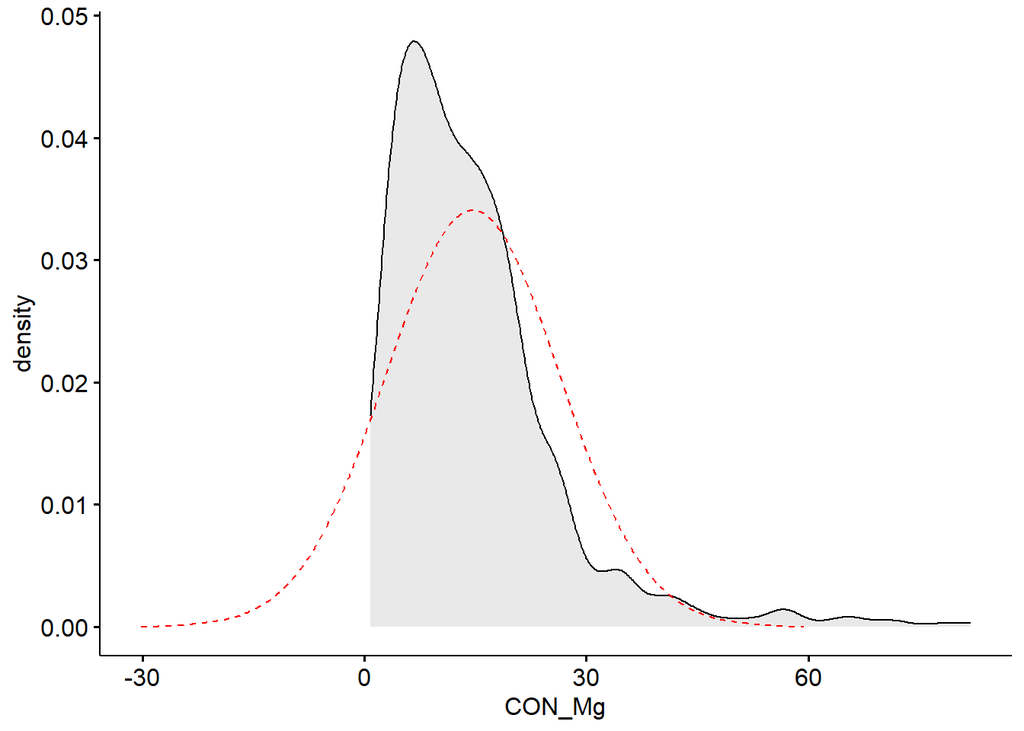

```r
ggdensity(dataset, x = "CON_Mg", fill = "lightgray") +
  scale_x_continuous() +
  stat_overlay_normal_density(color = "red", linetype = "dashed")
```

- According to ggdensity, the density of the CON_Mg observed in the groundwater appears to be right skewed.

**Confidence Interval** **Confidence interval of Odra Basin**

```r
Odra <- subset(dataset, BASIN_NAME=="Odra basin")
Vistula <- subset(dataset, BASIN_NAME=="Vistula basin")

Odra_conf <- t.test(Odra$TEMP_FIELD)$conf.int
Odra_conf
```

```
## [1] 10.95219 11.16615
## attr(,"conf.level")
## [1] 0.95
```

**Confidence interval of Vistula Basin**

```r
Vistula_conf <- t.test(Vistula$TEMP_FIELD)$conf.int
Vistula_conf
```

```
## [1] 10.71379 11.03137
## attr(,"conf.level")
## [1] 0.95
```

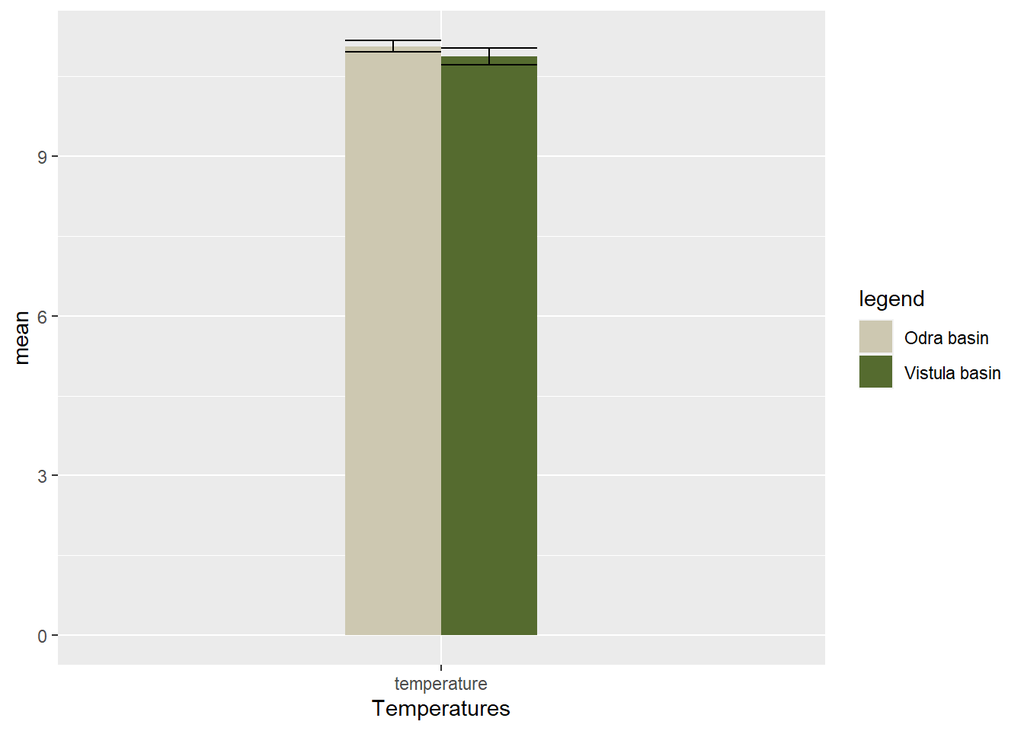

```r
temp.transfer <- data.frame(BASIN_NAME="Odra basin",Temperatures="temperature",
  mean=mean(Odra$TEMP_FIELD),
  lower=Odra_conf[1],
  upper=Odra_conf[2])

temp.transfer<- rbind(temp.transfer, data.frame(BASIN_NAME="Vistula basin",
  Temperatures="temperature",
  mean=mean(Vistula$TEMP_FIELD),
  lower=Vistula_conf[1],
  upper=Vistula_conf[2]))

ggplot(temp.transfer, aes(x=Temperatures, y=mean, fill=BASIN_NAME)) +
  geom_bar(position="dodge", stat="identity", width = 0.3) + geom_errorbar(aes(ymin=lower, ymax=upper), width=.3,
                position=position_dodge(.3)) + scale_fill_manual("legend", values = c("Odra basin" = "cornsilk3", "Vistula basin" = "darkolivegreen"))
```

- The above bar chart shows the visualization of the mean number of Temperature by Basins with confidence intervals. Mean ofTemperature field valeus are very close the each other.

-**CENTRAL LIMIT THEOREM** - The central limit theorem states that the sampling distribution of a sample mean is approximately normal if the sample size is large enough, even if the population distribution is not normal.

- The central limit theorem also states that the sampling distribution will have the following properties:
- 1. The mean of the sampling distribution will be equal to the mean of the population distribution:
- x = μ
- 2. The standard deviation of the sampling distribution will be equal to the standard deviation of the population distribution divided by the sample size:
- s = σ / n

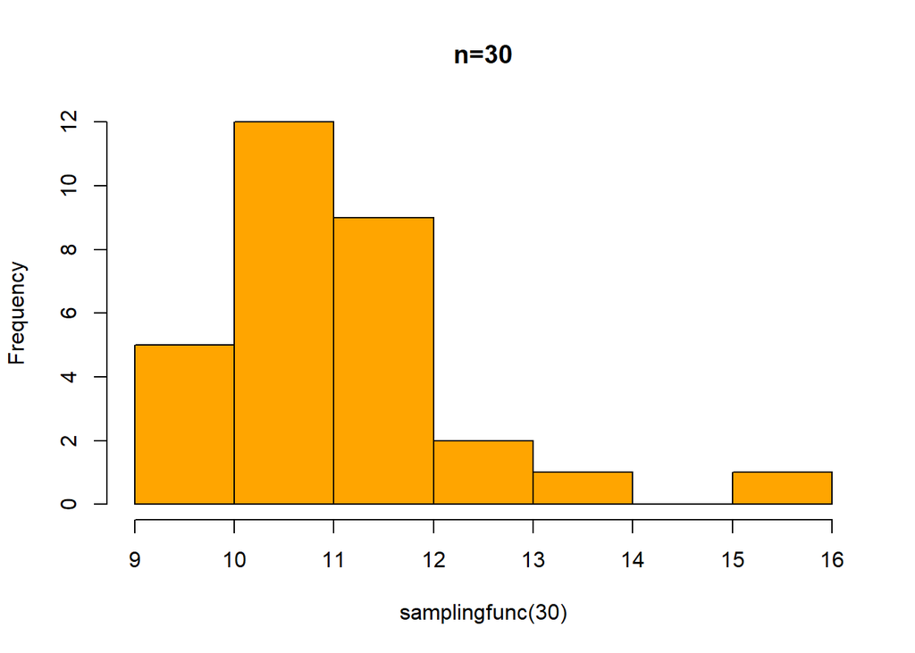

```r
samplingfunc<-function(size){
  tempfield <- dataset$TEMP_FIELD

  sample <- sample(tempfield, size)

  return(sample)
}
hist(col='orange',samplingfunc(30) , main = 'n=30')
```

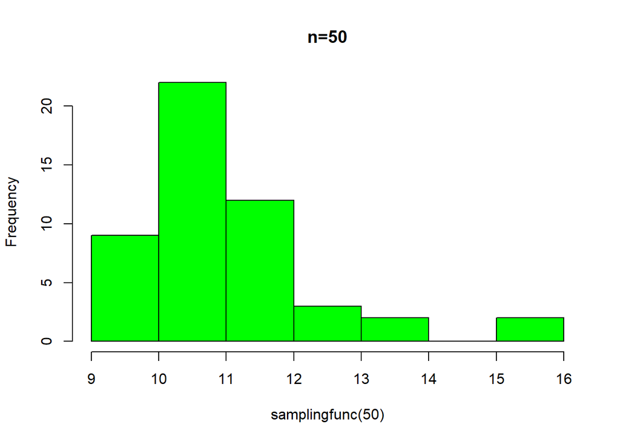

```r
hist(col='green', samplingfunc(50), main = 'n=50')
```

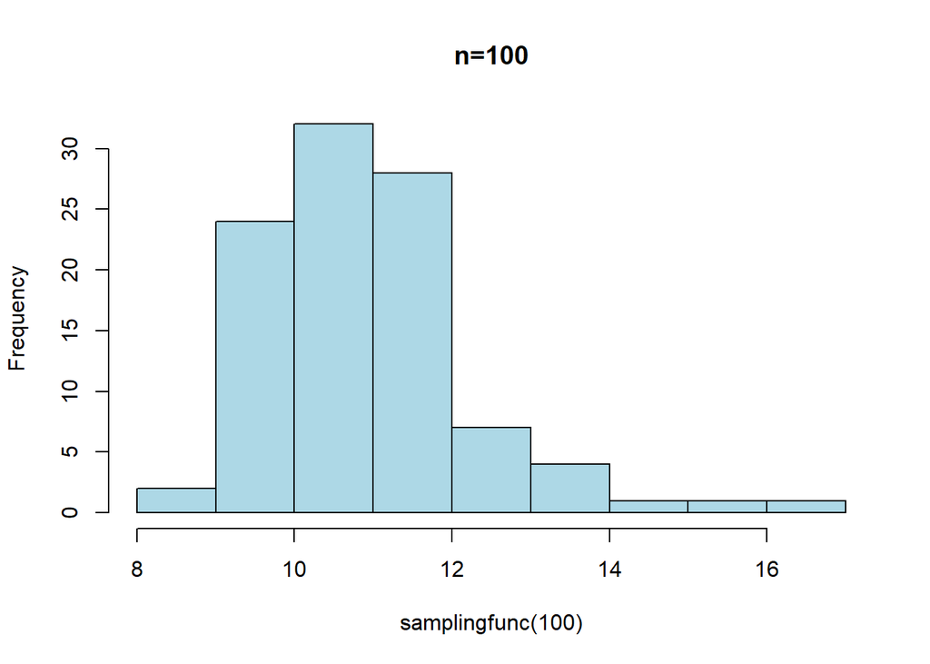

```r
hist(col ='light blue', samplingfunc(100), main = 'n=100')
```

- To increase normality, we randomly created a sampling function. It takes a size parameter and returns the sample. Thus, since the samples we created were in random and different sizes, they gave results closer to normal and reflected on the histograms.

-**TRANSFORMATION DATA**

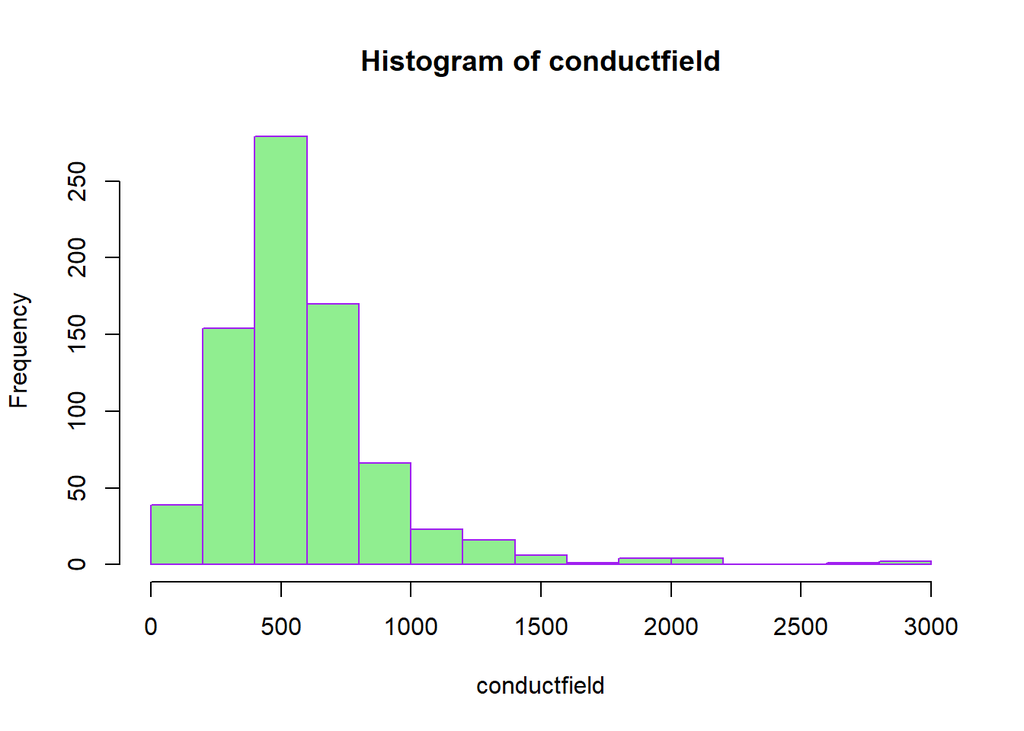

```r
conductfield <- dataset$CONDUCT_FIELD
hist(col ='light green', conductfield, border = 'purple')
```

```r
shapiro.test(conductfield)
```

```
##
##  Shapiro-Wilk normality test
##
## data:  conductfield
## W = 0.82218, p-value < 2.2e-16
```

```r
library(MASS)
```

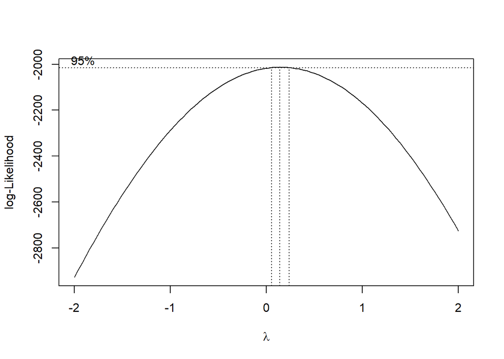

```r
boxcox(lm(conductfield ~ 1))
```

- The center dashed vertical line represents the estimated parameter λ<sup>λ</sup> and the others the 95% confidence interval of the estimation.

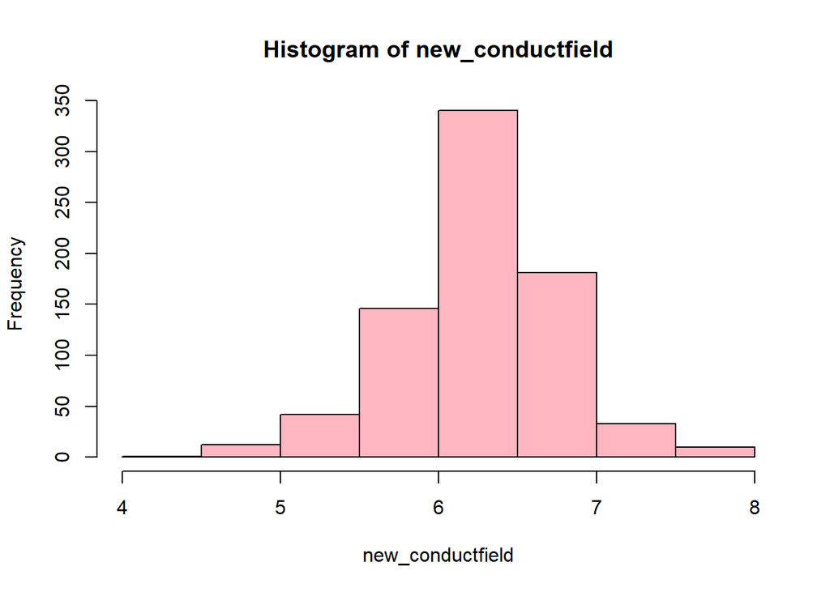

```r
# Transformed data
new_conductfield <- log(conductfield)

# Histogram
hist(col ='light pink',new_conductfield)
```

- Now the data looks more like following a normal distribution, we also performed,a statistical test to check it, as the Shapiro-Wilk test:

```r
shapiro.test(new_conductfield)
```

```
##
##  Shapiro-Wilk normality test
##
## data:  new_conductfield
## W = 0.97801, p-value = 2.558e-09
```

-**SINGLE T-TEST**

```r
shapiro.test(dataset$TEMP_FIELD)
```

```
##
##  Shapiro-Wilk normality test
##
## data:  dataset$TEMP_FIELD
## W = 0.88264, p-value < 2.2e-16
```

- The p-value is not greater than 0.05, so data is not normally distributed and the below plot indicates that.

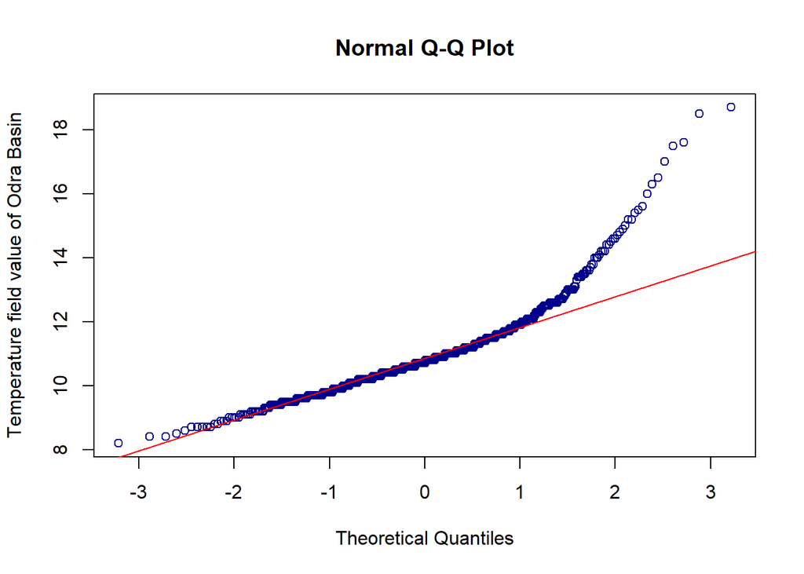

```r
qqnorm(col='dark blue',dataset$TEMP_FIELD, ylab = "Temperature field value of Odra Basin")
qqline(col='red',dataset$TEMP_FIELD)
```

```r
library(ggplot2)
skewness(dataset$TEMP_FIELD, na.rm = TRUE)
```

```
## [1] 1.753918
```

- Since the output value is >0, it is skewed to the right (asymmetrical)

```r
wilcox.test(dataset$TEMP_FIELD, mu = 10, conf.int = TRUE, conf.level = 0.95)
```

```
##
##  Wilcoxon signed rank test with continuity correction
##
## data:  dataset$TEMP_FIELD
## V = 252549, p-value < 2.2e-16
## alternative hypothesis: true location is not equal to 10
## 95 percent confidence interval:
##  10.75002 10.90002
## sample estimates:
## (pseudo)median
##       10.84996
```

-**Possible Errors:** - Type1 Error -> Mean = 10 but we rejected the null hypothesis. - Type2 Error -> Mean != 10 but we did not reject the null hypothesis.

-**TWO SAMPLE TEST**

```r
tempdata = read.csv("C:\\Users\\petek\\Desktop\\Groundwater_parameters.csv")
tempdata$BASIN_NAME[tempdata$BASIN_NAME!="Odra basin"]<-"Other basin"
```

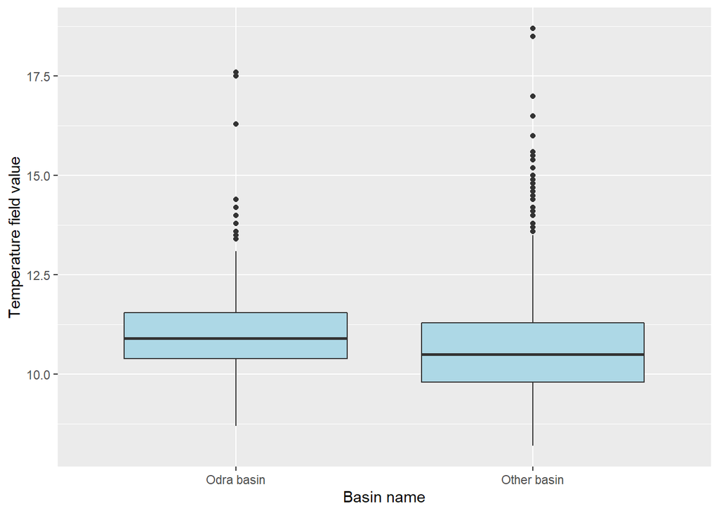

```r
qplot(x = BASIN_NAME, y = TEMP_FIELD,
      geom = "boxplot", data = tempdata,
      xlab = "Basin name",
      ylab = "Temperature field value",
      fill = I("lightblue"))
```

- This plot is not sufficient enough to interpret the association between basin names and the temperature field values. To see more detail, compute a summary table.

```r
tempdata %>%
  group_by(BASIN_NAME) %>%
  summarize(num.obs = n(),
            mean.tempdata = mean(TEMP_FIELD),
            sd.tempdata = sd(TEMP_FIELD),
            se.tempdata = sd(TEMP_FIELD) / sqrt(num.obs))
```

```
## # A tibble: 2 x 5
##   BASIN_NAME  num.obs mean.tempdata sd.tempdata se.tempdata
##   <chr>         <int>         <dbl>       <dbl>       <dbl>
## 1 Odra basin      387          11.1        1.07      0.0544
## 2 Other basin     382          10.8        1.55      0.0793
```

- Check population variances.

```r
Odra.sub <- subset(tempdata, BASIN_NAME=="Odra basin")$TEMP_FIELD
Other.sub <- subset(tempdata, BASIN_NAME=="Other basin")$TEMP_FIELD
var.test(Odra.sub, Other.sub)
```

```
##
##  F test to compare two variances
##
## data:  Odra.sub and Other.sub
## F = 0.47739, num df = 386, denom df = 381, p-value = 8.008e-13
## alternative hypothesis: true ratio of variances is not equal to 1
## 95 percent confidence interval:
##  0.3906479 0.5833268
## sample estimates:
## ratio of variances
##          0.4773946
```

```r
t.test(TEMP_FIELD  ~ BASIN_NAME, data = tempdata, var.equal = TRUE, paired = FALSE)
```

```
##
##  Two Sample t-test
##
## data:  TEMP_FIELD by BASIN_NAME
## t = 2.2053, df = 767, p-value = 0.02773
## alternative hypothesis: true difference in means between group Odra basin and group Other basin is not equal to 0
## 95 percent confidence interval:
##  0.02323109 0.39982720
## sample estimates:
##  mean in group Odra basin mean in group Other basin
##                  11.05917                  10.84764
```

- WE chose this test because we want to compare two different data columns.
- **Conclusion :** Since p-value < 0.05, we reject the null hypothesis, so there is a difference between mean of temperature field value for Odra basin and Other basins.

-**Fisher’s exact test** - Aim: Fisher’s exact test is a non-parametric method for comparing the proportion of categories in two different independent groups (categorical [nominal] variables) in a contingency table. We choose Basin and Categorical Land as categorical data. - Hypothesis : - H0 = Basin and category land are independent. - H1 = Basin and category land are dependent.

```r
tempdata2 = read.csv("C:\\Users\\petek\\Desktop\\Groundwater_parameters.csv")
tempdata2$BASIN_NAME[tempdata2$BASIN_NAME!="Odra basin"]<-"Other basin"
tempdata2$CAT_LAND[tempdata2$CAT_LAND!="04. Rural buildings"]<-"Other catland"

dataforfisher <- tempdata2[, c(9, 10)]
colnames(dataforfisher) <- c("Basin", "catland")

BasinName <- dataforfisher$Basin
Catland <- dataforfisher$catland

#In order to apply the Fisher Exact Test correctly, we visualized the two categorical variables we used in a contingency table.
table <- table(BasinName,Catland)
table
```

```
##              Catland
## BasinName     04. Rural buildings Other catland
##   Odra basin                  113           274
##   Other basin                 142           240
```

```r
fisher.test(table, conf.int = 0.95)
```

```
##
##  Fisher's Exact Test for Count Data
##
## data:  table
## p-value = 0.02152
## alternative hypothesis: true odds ratio is not equal to 1
## 95 percent confidence interval:
##  0.5094065 0.9532103
## sample estimates:
## odds ratio
##  0.6973692
```

```r
data <- dataset[, c(9, 14)]
names(data) <- c("Basin", "Temperature")
```

- Summary table for the mean and standard deviation for basins.

```r
group_by(data, Basin) %>%
  summarise(
    count = n(),
    mean = mean(Temperature, na.rm = TRUE),
    sd = sd(Temperature, na.rm = TRUE)
  )
```

```
## # A tibble: 3 x 4
##   Basin         count  mean    sd
##   <chr>         <int> <dbl> <dbl>
## 1 Danube basin     10  9.92 0.790
## 2 Odra basin      387 11.1  1.07
## 3 Vistula basin   372 10.9  1.56
```

- It looks like there is some association, but we do not yet know if it is statistically significant.

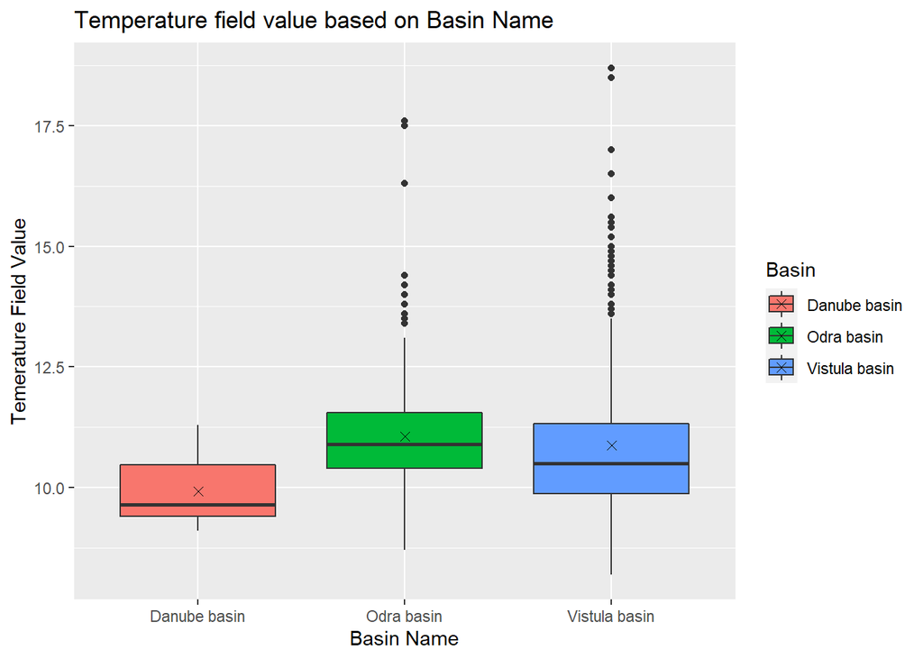

```r
ggplot(data=data, aes(x=Basin, y=Temperature, fill= Basin)) +
  geom_boxplot() +
  labs(title = "Temperature field value based on Basin Name", x = "Basin Name", y="Temerature Field Value") +
  stat_summary(fun=mean, geom="point", shape=4, size=2)
```

- The box plot shows that their means are close to each other.

```r
shapiro.test(data[data$Basin=="Odra basin", 2][0:5000])
```

```
##
##  Shapiro-Wilk normality test
##
## data:  data[data$Basin == "Odra basin", 2][0:5000]
## W = 0.89006, p-value = 4.821e-16
```

```r
model<-aov(Temperature ~ Basin, data = data)
summary(model)
```

```
##              Df Sum Sq Mean Sq F value  Pr(>F)
## Basin         2   17.4   8.719   4.955 0.00727 **
## Residuals   766 1347.8   1.760
## ---
## Signif. codes:  0 '***' 0.001 '**' 0.01 '*' 0.05 '.' 0.1 ' ' 1
```

- As the p-value is less than the significance level 0.05, we reject H0 and we can conclude that there are significant differences between Basins.In other words, average number of temperature field values varies across the three basin groups considered in the data.
- **TUKEY TEST**

```r
TukeyHSD(model, conf.level=.95)
```

```
##   Tukey multiple comparisons of means
##     95% family-wise confidence level
##
## Fit: aov(formula = Temperature ~ Basin, data = data)
##
## $Basin
##                                  diff         lwr        upr     p adj
## Odra basin-Danube basin     1.1391731  0.14149932 2.13684693 0.0204515
## Vistula basin-Danube basin  0.9525806 -0.04559969 1.95076098 0.0651105
## Vistula basin-Odra basin   -0.1865925 -0.41276651 0.03958155 0.1289711
```

- Odra basin vs Danube basin are significantly different at the 95 percent confidence level, according to the Tukey HSD test.
- **MULTIPLE LINEAR REGRESSION**
- Aim: Our aim of to use multiple linear regression is to model the linear relationship between the explanatory (independent) variables and response (dependent) variables.We chose pH field and temperature field and conduct field.
- Hypothesis :
- H0:βJ=0 (there is no (linear) relationship between the three variables)
- H1:βJ≠0 (there is a (linear) relationship between the three variables)

```r
dataforregression <- dataset[, c(13,14,12)]
names(dataforregression) <- c("pH", "Temperature", "conduct")
model <- lm(pH~Temperature+conduct, data = dataforregression)
model2 <- lm(conduct~Temperature+pH, data = dataforregression)
model3 <- lm(Temperature~conduct+pH, data = dataforregression)

coefofpH <- coef(model)[1]
coefoftemperature <- coef(model)[2]
coefofconduct <- coef(model)[3]

print(coefofpH)
```

```
## (Intercept)
##    7.342058
```

```r
print(coefoftemperature)
```

```
## Temperature
## -0.02375294
```

```r
print(coefofconduct)
```

```
##      conduct
## 0.0001041821
```

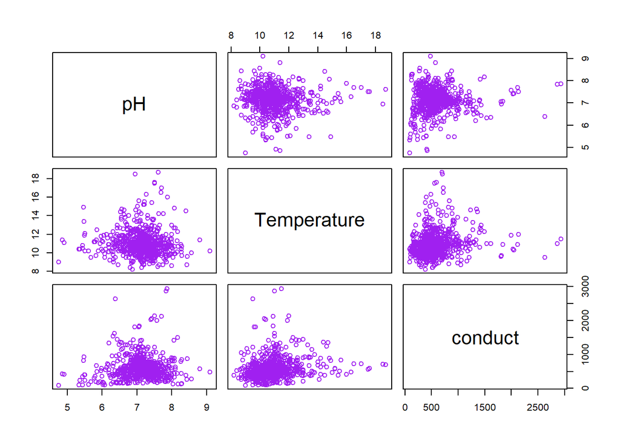

```r
plot(col='purple',dataforregression)
```

```r
summary(model)
```

```
##
## Call:
## lm(formula = pH ~ Temperature + conduct, data = dataforregression)
##
## Residuals:
##      Min       1Q   Median       3Q      Max
## -2.38724 -0.23312  0.04834  0.27730  1.94980
##
## Coefficients:
##               Estimate Std. Error t value Pr(>|t|)
## (Intercept)  7.342e+00  1.552e-01  47.322   <2e-16 ***
## Temperature -2.375e-02  1.420e-02  -1.672   0.0949 .
## conduct      1.042e-04  5.869e-05   1.775   0.0763 .
## ---
## Signif. codes:  0 '***' 0.001 '**' 0.01 '*' 0.05 '.' 0.1 ' ' 1
##
## Residual standard error: 0.5158 on 762 degrees of freedom
##   (4 observations deleted due to missingness)
## Multiple R-squared:  0.006725,   Adjusted R-squared:  0.004118
## F-statistic:  2.58 on 2 and 762 DF,  p-value: 0.07646
```

```r
summary(model2)
```

```
##
## Call:
## lm(formula = conduct ~ Temperature + pH, data = dataforregression)
##
## Residuals:
##     Min      1Q  Median      3Q     Max
## -494.10 -195.38  -52.17  110.11 2296.28
##
## Coefficients:
##             Estimate Std. Error t value Pr(>|t|)
## (Intercept) -105.109    189.630  -0.554   0.5795
## Temperature   37.838      8.658   4.370 1.41e-05 ***
## pH            39.529     22.268   1.775   0.0763 .
## ---
## Signif. codes:  0 '***' 0.001 '**' 0.01 '*' 0.05 '.' 0.1 ' ' 1
##
## Residual standard error: 317.7 on 762 degrees of freedom
##   (4 observations deleted due to missingness)
## Multiple R-squared:  0.02746,    Adjusted R-squared:  0.0249
## F-statistic: 10.76 on 2 and 762 DF,  p-value: 2.473e-05
```

```r
summary(model3)
```

```
##
## Call:
## lm(formula = Temperature ~ conduct + pH, data = dataforregression)
##
## Residuals:
##     Min      1Q  Median      3Q     Max
## -2.8798 -0.7620 -0.2185  0.4595  7.7600
##
## Coefficients:
##               Estimate Std. Error t value Pr(>|t|)
## (Intercept) 11.6622031  0.6602331  17.664  < 2e-16 ***
## conduct      0.0006462  0.0001479   4.370 1.41e-05 ***
## pH          -0.1539189  0.0920480  -1.672   0.0949 .
## ---
## Signif. codes:  0 '***' 0.001 '**' 0.01 '*' 0.05 '.' 0.1 ' ' 1
##
## Residual standard error: 1.313 on 762 degrees of freedom
##   (4 observations deleted due to missingness)
## Multiple R-squared:  0.02701,    Adjusted R-squared:  0.02445
## F-statistic: 10.57 on 2 and 762 DF,  p-value: 2.951e-05
```

```r
dataforregression <- dataset[, c(13,14,12,15)]
names(dataforregression) <- c("pH", "Temperature", "conduct", "o2dissol")
model <- lm(pH~Temperature+conduct+o2dissol, data = dataforregression)
print(model)
```

```
##
## Call:
## lm(formula = pH ~ Temperature + conduct + o2dissol, data = dataforregression)
##
## Coefficients:
## (Intercept)  Temperature      conduct     o2dissol
##   7.3532167   -0.0284714    0.0001132    0.0158711
```

```r
summary(model)
```

```
##
## Call:
## lm(formula = pH ~ Temperature + conduct + o2dissol, data = dataforregression)
##
## Residuals:
##      Min       1Q   Median       3Q      Max
## -2.35798 -0.24711  0.04449  0.28016  1.97843
##
## Coefficients:
##               Estimate Std. Error t value Pr(>|t|)
## (Intercept)  7.353e+00  1.547e-01  47.525   <2e-16 ***
## Temperature -2.847e-02  1.429e-02  -1.992   0.0467 *
## conduct      1.132e-04  5.862e-05   1.931   0.0538 .
## o2dissol     1.587e-02  6.545e-03   2.425   0.0155 *
## ---
## Signif. codes:  0 '***' 0.001 '**' 0.01 '*' 0.05 '.' 0.1 ' ' 1
##
## Residual standard error: 0.5142 on 761 degrees of freedom
##   (4 observations deleted due to missingness)
## Multiple R-squared:  0.01434,    Adjusted R-squared:  0.01046
## F-statistic: 3.691 on 3 and 761 DF,  p-value: 0.01173
```